# A meditation on similarity statistics

# 1 Setup

```r
library(magrittr)
library(tidyverse)
library(arrow)
```

```r
source("../../R/cytominer-eval.R")
source("../../R/cytoplot.R")
```

```r
set.seed(42)
```

# 2 Load data

```r
# read these features
# https://github.com/broadinstitute/grit-benchmark/blob/31d9812e0c267d3535c85a72ef6bd0104d1a2130/1.calculate-metrics/cell-health/0.calculate-grit.ipynb
# (See chunk 4)

profiles <-
  read_csv("data/cell_health_merged_feature_select.csv.gz") %>%
  select(-Metadata_WellCol, -Metadata_WellRow)

metadata <- get_annotation(profiles)
variables <- drop_annotation(profiles)
```

```r
sim_df <- sim_calculate(profiles)
```

# 3 Inspect data

## 3.1 Structure

Random sampling of rows

```r
metadata %>% sample_n(5)
```

| id | Metadata_Plate | Metadata_Well | Metadata_cell_line | Metadata_gene_name | Metadata_pert_name |
| --- | --- | --- | --- | --- | --- |
| 2609 | SQ00014612 | M17 | A549 | GPX4 | GPX4-1 |
| 2369 | SQ00014612 | C17 | A549 | ERBB3 | ERBB3-2 |
| 1177 | SQ00014617 | B01 | HCC44 | Chr2 | Chr2-1 |
| 1098 | SQ00014616 | N18 | HCC44 | PSMA1 | PSMA1-1 |
| 1252 | SQ00014617 | E04 | HCC44 | COX5B | COX5B-1 |

Random sampling of columns

```r
variables %>% select(sample(ncol(variables), 5)) %>% sample_n(5)
```

| Cytoplasm_Correlation_Overlap_Mito_AGP | Cytoplasm_AreaShape_Zernike_8_4 | Cells_Granularity_3_Mito | Cytoplasm_AreaShape_Zernike_9_9 | Nuclei_Granularity_4_Mito |
| --- | --- | --- | --- | --- |
| -1.57365676 | -4.3844873 | -3.3563914 | -4.0958128 | -1.5521869 |
| 0.61879153 | -0.2289426 | 0.1632638 | -2.5962150 | 0.9757856 |
| 0.64308955 | -1.7289118 | -1.4805174 | -1.4945134 | -0.7066044 |
| 0.97510162 | -1.0438688 | -0.4898756 | -1.5062482 | -0.8284356 |
| -0.04310037 | 0.7265278 | -0.5928207 | 0.1826348 | -0.5677807 |

## 3.2 Counts

### 3.2.1 Totals

Total number

```r
count(metadata)
```

| n |
| --- |
| 3456 |

### 3.2.2 Stratified

Per plate

```r
metadata %>% group_by(Metadata_Plate) %>% tally()
```

| Metadata_Plate | n |
| --- | --- |
| SQ00014610 | 384 |
| SQ00014611 | 384 |
| SQ00014612 | 384 |
| SQ00014613 | 384 |
| SQ00014614 | 384 |
| SQ00014615 | 384 |
| SQ00014616 | 384 |
| SQ00014617 | 384 |
| SQ00014618 | 384 |

Per cell line

```r
metadata %>% group_by(Metadata_Plate, Metadata_cell_line) %>% tally()
```

| Metadata_Plate | Metadata_cell_line | n |
| --- | --- | --- |
| SQ00014610 | A549 | 384 |
| SQ00014611 | A549 | 384 |
| SQ00014612 | A549 | 384 |
| SQ00014613 | ES2 | 384 |
| SQ00014614 | ES2 | 384 |
| SQ00014615 | ES2 | 384 |
| SQ00014616 | HCC44 | 384 |
| SQ00014617 | HCC44 | 384 |
| SQ00014618 | HCC44 | 384 |

Per gene

```r
metadata %>% group_by(Metadata_cell_line, Metadata_gene_name) %>% tally() %>% ungroup %>% sample_n(5)
```

| Metadata_cell_line | Metadata_gene_name | n |
| --- | --- | --- |
| A549 | CTNNB1 | 12 |
| HCC44 | Luc | 24 |
| ES2 | STAT3 | 12 |
| ES2 | SLC2A1 | 6 |
| HCC44 | CCNE1 | 12 |

`n_genes` have `n_wells`

```r
metadata %>%
  group_by(Metadata_cell_line, Metadata_gene_name) %>%
  tally(name = "n_wells") %>%
  group_by(Metadata_cell_line, n_wells) %>%
  tally(name = "n_genes") %>%
  select(Metadata_cell_line, n_genes, n_wells) %>%
  inner_join(metadata %>% distinct(Metadata_cell_line) %>% slice(1)) %>%
  arrange(desc(n_genes))
```

| Metadata_cell_line | n_genes | n_wells |
| --- | --- | --- |
| HCC44 | 43 | 12 |
| HCC44 | 5 | 6 |
| HCC44 | 4 | 48 |
| HCC44 | 3 | 18 |
| HCC44 | 2 | 24 |
| HCC44 | 1 | 144 |
| HCC44 | 1 | 168 |

Per perturbation

```r
metadata %>%
  group_by(Metadata_cell_line, Metadata_gene_name, Metadata_pert_name) %>%
  tally() %>%
  ungroup() %>%
  sample_n(5)
```

| Metadata_cell_line | Metadata_gene_name | Metadata_pert_name | n |
| --- | --- | --- | --- |
| HCC44 | GPX4 | GPX4-1 | 6 |
| A549 | POLR2D | POLR2D-2 | 24 |
| HCC44 | DOT1L | DOT1L-2 | 6 |
| A549 | SMARCB1 | SMARCB1-2 | 6 |
| A549 | ATF4 | ATF4-1 | 6 |

`n_perts` have `n_wells`

```r
metadata %>%
  group_by(Metadata_cell_line, Metadata_gene_name, Metadata_pert_name) %>%
  tally(name = "n_wells") %>%
  group_by(Metadata_cell_line, n_wells) %>%
  tally(name = "n_perts") %>%
  select(Metadata_cell_line, n_perts, n_wells) %>%
  inner_join(metadata %>% distinct(Metadata_cell_line) %>% slice(1)) %>%
  arrange(desc(n_perts))
```

| Metadata_cell_line | n_perts | n_wells |
| --- | --- | --- |
| HCC44 | 100 | 6 |
| HCC44 | 14 | 24 |
| HCC44 | 2 | 12 |
| HCC44 | 1 | 9 |
| HCC44 | 1 | 15 |
| HCC44 | 1 | 168 |

`n_genes` have `n_perts`

```r
metadata %>%
  distinct(Metadata_cell_line, Metadata_gene_name, Metadata_pert_name) %>%
  group_by(Metadata_cell_line, Metadata_gene_name) %>%
  tally(name = "n_perts") %>%
  group_by(Metadata_cell_line, n_perts) %>%
  tally(name = "n_genes") %>%
  select(Metadata_cell_line, n_genes, n_perts) %>%
  inner_join(metadata %>% distinct(Metadata_cell_line) %>% slice(1)) %>%
  arrange(desc(n_perts))
```

| Metadata_cell_line | n_genes | n_perts |
| --- | --- | --- |
| HCC44 | 1 | 6 |
| HCC44 | 3 | 3 |
| HCC44 | 49 | 2 |
| HCC44 | 6 | 1 |

Zoom in on a single plate

```r
metadata %>%
  inner_join(metadata %>% distinct(Metadata_Plate) %>% slice(1)) %>%
  group_by(Metadata_cell_line, Metadata_gene_name, Metadata_pert_name) %>%
  tally(name = "n_wells") %>%
  group_by(Metadata_cell_line, n_wells) %>%
  tally(name = "n_perts") %>%
  select(Metadata_cell_line, n_perts, n_wells) %>%
  inner_join(metadata %>% distinct(Metadata_cell_line, Metadata_Plate) %>% slice(1)) %>%
  arrange(desc(n_perts)) %>%
  select(Metadata_Plate, Metadata_cell_line, everything())
```

| Metadata_Plate | Metadata_cell_line | n_perts | n_wells |
| --- | --- | --- | --- |
| SQ00014618 | HCC44 | 100 | 2 |
| SQ00014618 | HCC44 | 14 | 8 |
| SQ00014618 | HCC44 | 2 | 4 |
| SQ00014618 | HCC44 | 1 | 3 |
| SQ00014618 | HCC44 | 1 | 5 |
| SQ00014618 | HCC44 | 1 | 56 |

```r
metadata %>%
  inner_join(metadata %>% distinct(Metadata_Plate) %>% slice(1)) %>%
  group_by(Metadata_cell_line, Metadata_gene_name, Metadata_pert_name) %>%
  tally(name = "n_wells") %>%
  filter(n_wells > 2) %>%
  arrange(Metadata_gene_name)
```

| Metadata_cell_line | Metadata_gene_name | Metadata_pert_name | n_wells |
| --- | --- | --- | --- |
| HCC44 | Chr2 | Chr2-1 | 8 |
| HCC44 | Chr2 | Chr2-2 | 8 |
| HCC44 | Chr2 | Chr2-3 | 8 |
| HCC44 | Chr2 | Chr2-4 | 8 |
| HCC44 | Chr2 | Chr2-5 | 8 |
| HCC44 | Chr2 | Chr2-6 | 8 |
| HCC44 | EMPTY | EMPTY | 56 |
| HCC44 | LacZ | LacZ-2 | 4 |
| HCC44 | LacZ | LacZ-3 | 4 |
| HCC44 | Luc | Luc-1 | 5 |

[output cut: 9 more lines]

```r
controls <- data.frame(Metadata_gene_name = c("Chr2", "Luc", "LacZ"))

metadata %>%
  inner_join(metadata %>% distinct(Metadata_Plate) %>% slice(1)) %>%
  inner_join(controls) %>%
  group_by(Metadata_cell_line, Metadata_gene_name, Metadata_pert_name) %>%
  tally(name = "n_wells")
```

| Metadata_cell_line | Metadata_gene_name | Metadata_pert_name | n_wells |
| --- | --- | --- | --- |
| HCC44 | Chr2 | Chr2-1 | 8 |
| HCC44 | Chr2 | Chr2-2 | 8 |
| HCC44 | Chr2 | Chr2-3 | 8 |
| HCC44 | Chr2 | Chr2-4 | 8 |
| HCC44 | Chr2 | Chr2-5 | 8 |
| HCC44 | Chr2 | Chr2-6 | 8 |
| HCC44 | LacZ | LacZ-2 | 4 |
| HCC44 | LacZ | LacZ-3 | 4 |
| HCC44 | Luc | Luc-1 | 5 |
| HCC44 | Luc | Luc-2 | 3 |

```r
metadata %>%
  inner_join(metadata %>% distinct(Metadata_Plate) %>% slice(1)) %>%
  inner_join(controls) %>%
  tally(name = "n_wells")
```

| n_wells |
| --- |
| 64 |

## 3.3 Key groups

### 3.3.1 Number of perturbations per gene

`n_genes` have `n_perts`

```r
metadata %>%
  distinct(Metadata_cell_line, Metadata_gene_name, Metadata_pert_name) %>%
  group_by(Metadata_cell_line, Metadata_gene_name) %>%
  tally(name = "n_perts") %>%
  group_by(Metadata_cell_line, n_perts) %>%
  tally(name = "n_genes") %>%
  select(Metadata_cell_line, n_genes, n_perts) %>%
  inner_join(metadata %>% distinct(Metadata_cell_line) %>% slice(1)) %>%
  arrange(desc(n_perts))
```

| Metadata_cell_line | n_genes | n_perts |
| --- | --- | --- |
| HCC44 | 1 | 6 |
| HCC44 | 3 | 3 |
| HCC44 | 49 | 2 |
| HCC44 | 6 | 1 |

### 3.3.2 Number of wells per perturbation

`n_perts` have `n_wells`

```r
metadata %>%
  group_by(Metadata_cell_line, Metadata_gene_name, Metadata_pert_name) %>%
  tally(name = "n_wells") %>%
  group_by(Metadata_cell_line, n_wells) %>%
  tally(name = "n_perts") %>%
  select(Metadata_cell_line, n_perts, n_wells) %>%
  inner_join(metadata %>% distinct(Metadata_cell_line) %>% slice(1)) %>%
  arrange(desc(n_perts))
```

| Metadata_cell_line | n_perts | n_wells |
| --- | --- | --- |
| HCC44 | 100 | 6 |
| HCC44 | 14 | 24 |
| HCC44 | 2 | 12 |
| HCC44 | 1 | 9 |
| HCC44 | 1 | 15 |
| HCC44 | 1 | 168 |

### 3.3.3 Number of control wells (per plate)

```r
controls <- data.frame(Metadata_gene_name = c("Chr2", "Luc", "LacZ"))

metadata %>%
  inner_join(metadata %>% distinct(Metadata_Plate) %>% slice(1)) %>%
  inner_join(controls) %>%
  group_by(Metadata_cell_line, Metadata_gene_name, Metadata_pert_name) %>%
  tally(name = "n_wells")
```

| Metadata_cell_line | Metadata_gene_name | Metadata_pert_name | n_wells |
| --- | --- | --- | --- |
| HCC44 | Chr2 | Chr2-1 | 8 |
| HCC44 | Chr2 | Chr2-2 | 8 |
| HCC44 | Chr2 | Chr2-3 | 8 |
| HCC44 | Chr2 | Chr2-4 | 8 |
| HCC44 | Chr2 | Chr2-5 | 8 |
| HCC44 | Chr2 | Chr2-6 | 8 |
| HCC44 | LacZ | LacZ-2 | 4 |
| HCC44 | LacZ | LacZ-3 | 4 |
| HCC44 | Luc | Luc-1 | 5 |
| HCC44 | Luc | Luc-2 | 3 |

```r
metadata %>%
  inner_join(metadata %>% distinct(Metadata_Plate) %>% slice(1)) %>%
  inner_join(controls) %>%
  tally(name = "n_wells")
```

| n_wells |
| --- |
| 64 |

# 4 Compute similarity sets

## 4.1 Filter out some rows

```r
drop_group <-
  data.frame(Metadata_gene_name = "EMPTY")
```

## 4.2 Similarity to reference

Fetch similarities between

1. all rows (except, optionally those containing `reference`)

and

2. all rows containing `reference`

Do so only for those (a, b) pairs that

- have *same* values in *all* columns of `all_same_cols_ref`

```r
reference <-
  data.frame(Metadata_gene_name = c("Chr2", "Luc", "LacZ"))

# all_same_cols_ref <-
#   c("Metadata_cell_line")

all_same_cols_ref <-
  c("Metadata_cell_line",
    "Metadata_Plate")
```

## 4.3 Similarity to replicates (no references)

Fetch similarities between

1. all rows except `reference` rows

and

2. all rows except `reference` rows (i.e. to each other)

Do so for only those (a, b) pairs that

- have *same* values in *all* columns of `all_same_cols_rep`

Keep, both, (a, b) and (b, a)

```r
all_same_cols_rep <-
  c("Metadata_cell_line",
    "Metadata_gene_name",
    "Metadata_pert_name")
```

## 4.4 Similarity to replicates (only references)

Fetch similarities between

1. all rows containing `reference`

and

2. all rows containing `reference` (i.e. to each other)

Do so for only those (a, b) pairs that

- have *same* values in *all* columns of `all_same_cols_rep_ref`.

Keep, both, (a, b) and (b, a)

```r
all_same_cols_rep_ref <-
  c(
    "Metadata_cell_line",
    "Metadata_gene_name",
    "Metadata_pert_name",
    "Metadata_Plate"
  )

# all_same_cols_rep_ref <-
#   c(
#     "Metadata_cell_line",
#     "Metadata_gene_name",
#     "Metadata_pert_name"
#   )
```

## 4.5 Similarity to non-replicates

Fetch similarities between

1. all rows (except, optionally, `reference` rows)

and

2. all rows except `reference` rows

Do so for only those (a, b) pairs that

- have *same* values in *all* columns of `all_same_cols_non_rep`
- have *different* values in *all* columns `all_different_cols_non_rep`
- have *different* values in *at least one* column of `any_different_cols_non_rep`

Keep, both, (a, b) and (b, a)

```r
any_different_cols_non_rep <-
  c("Metadata_cell_line",
    "Metadata_gene_name",
    "Metadata_pert_name")

all_same_cols_non_rep <-
  c("Metadata_cell_line",
    "Metadata_Plate")

all_different_cols_non_rep <-
  c("Metadata_gene_name")
```

## 4.6 Similarity to group

Fetch similarities between

1. all rows

and

2. all rows

Do so only for those (a, b) pairs that

- have *same* values in *all* columns of `all_same_cols_group`
- have *different* values in *at least one* column of `any_different_cols_group`

```r
all_same_cols_group <-
  c("Metadata_cell_line",
    "Metadata_gene_name")

any_different_cols_group <-
  c("Metadata_cell_line",
    "Metadata_gene_name",
    "Metadata_pert_name")
```

## 4.7 Combine all and annotate the similarity matrix

```r
annotation_cols <-
  c("Metadata_cell_line",
    "Metadata_gene_name",
    "Metadata_pert_name")

collated_sim <-
  sim_collate(
    sim_df,
    reference,
    all_same_cols_rep = all_same_cols_rep,
    all_same_cols_rep_ref = all_same_cols_rep_ref,
    all_same_cols_ref = all_same_cols_ref,
    any_different_cols_non_rep = any_different_cols_non_rep,
    all_same_cols_non_rep = all_same_cols_non_rep,
    all_different_cols_non_rep = all_different_cols_non_rep,
    any_different_cols_group = any_different_cols_group,
    all_same_cols_group = all_same_cols_group,
    annotation_cols = annotation_cols,
    drop_group = drop_group
  )
```

# 5 Compute metrics

```r
norm_non_rep_metrics <-
  sim_metrics(collated_sim, "non_rep", calculate_grouped = TRUE)

norm_ref_metrics <-
  sim_metrics(collated_sim, "ref", calculate_grouped = TRUE)

per_row_metrics <-
  inner_join(
    norm_non_rep_metrics[["per_row"]],
    norm_ref_metrics[["per_row"]]
  )
per_set_metrics <-
  inner_join(
    norm_non_rep_metrics[["per_set"]],
    norm_ref_metrics[["per_set"]]
  )
per_set_group_metrics <-
  inner_join(
    norm_non_rep_metrics[["per_set_group"]],
    norm_ref_metrics[["per_set_group"]]
  )
per_set_all_metrics <-
  per_set_group_metrics %>%
  inner_join(per_set_metrics, by = c(all_same_cols_rep))
```

```r
metrics <-
  per_set_all_metrics %>%
  mutate(
    grit_group = sim_scaled_mean_ref_g,
    grit_indiv = sim_scaled_mean_ref_i_mean_i
  ) %>%
  select(all_of(all_same_cols_rep), everything())
```

# 6 Inspect metrics

```r
rename_cols <- function(coln) {
  coln %>%
    str_remove_all("sim_")
}
```

[figure not shown]

```r
per_set_all_metrics %>%
  rename_with(rename_cols, starts_with("sim_")) %>%
  select(-matches("Metadata"), -matches("stat")) %>%
  select(matches("^scaled_"), matches("stat"), everything()) %>%
  cor() %>%
  corrplot::corrplot(tl.pos = "ld", type = "lower", order = "hclust", method = "ellipse")
```

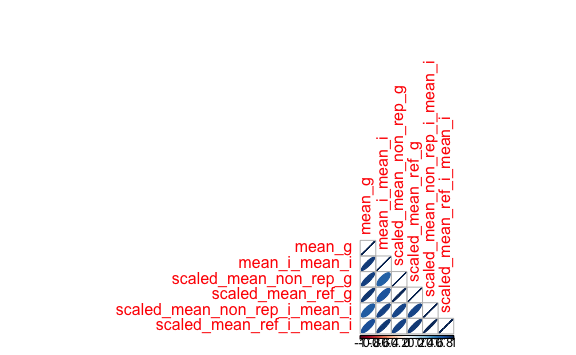

```r
per_set_all_metrics %>%
  rename_with(rename_cols, starts_with("sim_")) %>%
  select(-matches("Metadata|median"), -matches("stat")) %>%
  select(matches("^scaled_"), matches("stat"), everything()) %>%
  cor() %>%
  corrplot::corrplot(tl.pos = "ld", type = "lower", order = "hclust", method = "ellipse")
```

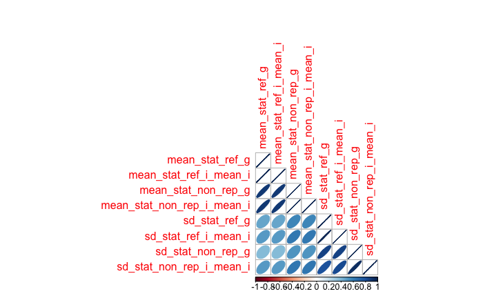

```r
per_set_all_metrics %>%
  rename_with(rename_cols, starts_with("sim_")) %>%
  select(-matches("Metadata|median")) %>%
  select(matches("stat")) %>%
  cor() %>%
  corrplot::corrplot(tl.pos = "ld", type = "lower", order = "hclust", method = "ellipse")
```

[figure not shown]

```r
per_set_all_metrics %>%
  rename_with(rename_cols, starts_with("sim_")) %>%
  select(-matches("Metadata|median")) %>%
  select(matches("^scaled_"), matches("stat"), everything()) %>%
  cor() %>%
  corrplot::corrplot(tl.pos = "ld", type = "lower", order = "hclust", method = "ellipse")
```

# 7 Focus on one guide

```r
target_guide <- data.frame(
  Metadata_cell_line = "A549",
  Metadata_gene_name = "ITGAV",
  Metadata_pert_name = "ITGAV-1")

sister_guide <- data.frame(
  Metadata_cell_line = "A549",
  Metadata_gene_name = "ITGAV",
  Metadata_pert_name = "ITGAV-2")

cutting_controls <- data.frame(
  Metadata_cell_line = c("A549", "A549", "A549"),
  Metadata_gene_name = c("Chr2", "Luc", "LacZ")
)

metadata <-
  profiles %>%
  select(matches("Metadata"))
```

```r
plate <- "SQ00014611"
metadata_include <- list(target_guide,
                         drop_group,
                         sister_guide,
                         cutting_controls) %>%
  map_df(function(df) {
    metadata %>%
      filter(Metadata_Plate == plate) %>%
      inner_join(df)
  })

metadata_filtered <-
  metadata  %>%
  filter(Metadata_Plate == plate) %>%
  anti_join(metadata_include) %>%
  mutate(Metadata_pert_name = "Other perturbations") %>%
  mutate(Metadata_gene_name = "Other perturbations") %>%
  bind_rows(metadata_include) %>%
  mutate(Metadata_pert_name = case_when(
    Metadata_gene_name %in% cutting_controls$Metadata_gene_name ~ "Cutting controls",
    TRUE ~ Metadata_pert_name
  ))%>%
  mutate(Metadata_gene_name = case_when(
    Metadata_gene_name %in% cutting_controls$Metadata_gene_name ~ "Cutting controls",
    TRUE ~ Metadata_gene_name
  ))
```

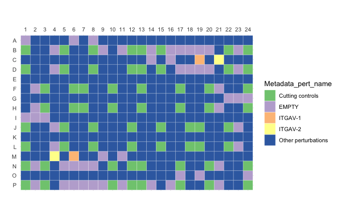

```r
p <-
  metadata_filtered %>%
  plot_plate("Metadata_pert_name", well_position = "Metadata_Well")

p + scale_fill_brewer(palette="Accent")
```

```r
features <- function(df) t(as.matrix(df %>% select(-matches("^Metadata_"))))

plate <- function(df) df$Metadata_Plate

p_target_guide <- profiles %>% inner_join(target_guide)
p_sister_guide <- profiles %>% inner_join(sister_guide)
p_cutting_controls <- profiles %>% inner_join(cutting_controls)
```

```r
p_target_guide %>% group_by(across(all_of(unique(c(all_same_cols_rep, all_same_cols_ref))))) %>% tally()
```

| Metadata_cell_line | Metadata_gene_name | Metadata_pert_name | Metadata_Plate | n |
| --- | --- | --- | --- | --- |
| A549 | ITGAV | ITGAV-1 | SQ00014610 | 2 |
| A549 | ITGAV | ITGAV-1 | SQ00014611 | 2 |
| A549 | ITGAV | ITGAV-1 | SQ00014612 | 2 |

```r
p_sister_guide %>% group_by(across(all_of(unique(c(all_same_cols_rep, all_same_cols_ref))))) %>% tally()
```

| Metadata_cell_line | Metadata_gene_name | Metadata_pert_name | Metadata_Plate | n |
| --- | --- | --- | --- | --- |
| A549 | ITGAV | ITGAV-2 | SQ00014610 | 2 |
| A549 | ITGAV | ITGAV-2 | SQ00014611 | 2 |
| A549 | ITGAV | ITGAV-2 | SQ00014612 | 2 |

```r
p_cutting_controls %>% group_by(across(all_of(all_same_cols_ref))) %>% tally()
```

| Metadata_cell_line | Metadata_Plate | n |
| --- | --- | --- |
| A549 | SQ00014610 | 64 |
| A549 | SQ00014611 | 64 |
| A549 | SQ00014612 | 64 |

```r
all_sim_counts <-
  collated_sim %>%
  group_by(across(all_of(c("id1", all_same_cols_rep, "type")))) %>%
  tally() %>%
  arrange(across(all_of(all_same_cols_rep))) %>%
  pivot_wider(names_from = "type",
              names_prefix = "n_",
              values_from = n,
              values_fill = 0)
```

```r
all_sim_counts %>%
  inner_join(target_guide)
```

| id1 | Metadata_cell_line | Metadata_gene_name | Metadata_pert_name | n_non_rep | n_ref | n_rep | n_rep_group |
| --- | --- | --- | --- | --- | --- | --- | --- |
| 451 | A549 | ITGAV | ITGAV-1 | 260 | 64 | 5 | 6 |
| 678 | A549 | ITGAV | ITGAV-1 | 260 | 64 | 5 | 6 |
| 1603 | A549 | ITGAV | ITGAV-1 | 260 | 64 | 5 | 6 |
| 1830 | A549 | ITGAV | ITGAV-1 | 260 | 64 | 5 | 6 |
| 2371 | A549 | ITGAV | ITGAV-1 | 260 | 64 | 5 | 6 |
| 2598 | A549 | ITGAV | ITGAV-1 | 260 | 64 | 5 | 6 |

```r
sim_collated_query <-
  function(msim, query, get_reference = NULL, all_same_cols_ref = NULL) {
    result <-
      msim %>% inner_join(query, by = colnames(query))

    if (!is.null(reference)) {

      query %<>% select(any_of(all_same_cols_ref))

      result %<>%
        bind_rows(
          msim %>%
            inner_join(reference, by = colnames(reference)) %>%
            inner_join(query, by = colnames(query)) %>%
            filter(type == "rep") %>%
            mutate(type = "ref_rep")
        )
    }

  }
```

```r
target_distributions <-
  sim_collated_query(collated_sim, target_guide, reference, all_same_cols_ref)

target_distributions %>%
  group_by(type) %>%
  tally()
```

| type | n |
| --- | --- |
| non_rep | 1560 |
| ref | 384 |
| ref_rep | 1158 |
| rep | 30 |
| rep_group | 36 |

```r
display_metrics_distributions <- function(target_guide) {
  target_distributions <-
    sim_collated_query(collated_sim, target_guide, reference, all_same_cols_ref) %>%
    mutate(type = factor(type, levels = c("rep", "rep_group", "ref", "ref_rep", "non_rep"))) %>%
    mutate(id1 = ifelse(type == "ref_rep", -1, id1)) %>%
    mutate(type =
             recode(type,
                    non_rep = "similarity to non-replicates",
                    ref_rep = "similarity among reference replicates (fixed)",
                    ref = "similarity to reference",
                    rep = "similarity among replicates",
                    rep_group = "similarity to group replicates",
                    )
           )

  p <-
    target_distributions %>%
    ggplot(aes(sim, fill = as.factor(id1))) +
    geom_histogram(binwidth = .02) +
    facet_wrap(~type, ncol = 1, scales = "free_y") +
    guides(fill=FALSE)

  df <-
    per_set_all_metrics %>%
    select(-matches("stat|median")) %>%
    inner_join(target_guide, by = colnames(target_guide)) %>%
    pivot_longer(-all_of(str_subset(colnames(per_set_all_metrics), "Metadata_")))

  print(p)

  df
}
```

```
`guides(<scale> = FALSE)` is deprecated. Please use `guides(<scale> = "none")` instead.
```

| Metadata_cell_line | Metadata_gene_name | Metadata_pert_name | name | value |
| --- | --- | --- | --- | --- |
| A549 | ITGAV | ITGAV-1 | sim_scaled_mean_non_rep_g | 2.3533055 |
| A549 | ITGAV | ITGAV-1 | sim_mean_g | 0.8720281 |
| A549 | ITGAV | ITGAV-1 | sim_scaled_mean_ref_g | 2.6731662 |
| A549 | ITGAV | ITGAV-1 | sim_scaled_mean_non_rep_i_mean_i | 2.3384116 |
| A549 | ITGAV | ITGAV-1 | sim_mean_i_mean_i | 0.8469545 |
| A549 | ITGAV | ITGAV-1 | sim_scaled_mean_ref_i_mean_i | 2.6778284 |

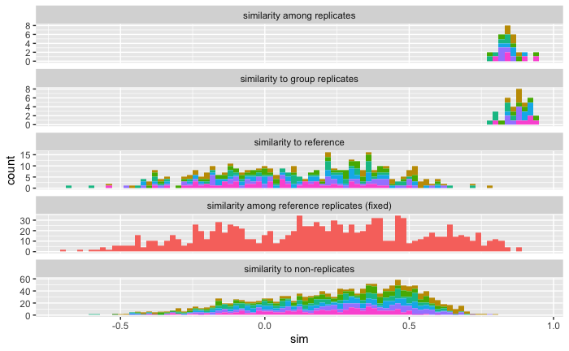

```r
target_guide <- data.frame(
  Metadata_cell_line = "A549",
  Metadata_gene_name = "ITGAV",
  Metadata_pert_name = "ITGAV-1")

display_metrics_distributions(target_guide)
```

```r
target_guide <- data.frame(
  Metadata_cell_line = "A549",
  Metadata_gene_name = "ITGAV",
  Metadata_pert_name = "ITGAV-1")

target_distributions <-
  sim_collated_query(collated_sim, target_guide, reference, all_same_cols_ref) %>%
  mutate(type = factor(type, levels = c("rep", "rep_group", "ref", "ref_rep", "non_rep"))) %>%
  mutate(type =
           recode(type,
                  non_rep = "similarity_to_non_replicates",
                  ref_rep = "similarity_among_reference_replicates",
                  ref = "similarity_to_reference",
                  rep = "similarity_among_replicates",
                  rep_group = "similarity_to_group_replicates",
                  )
         )
```

```r
# Output data
for (type in unique(target_distributions$type)) {
  target_distributions %>%
    filter(type == {{type}}) %>%
    write_csv(glue::glue("~/Desktop/{type}.csv"))
}

# Output full data
target_distributions %>% readr::write_csv(file.path("data", "grit_deconstructed.csv.gz"))
```

```
`guides(<scale> = FALSE)` is deprecated. Please use `guides(<scale> = "none")` instead.
```

| Metadata_cell_line | Metadata_gene_name | Metadata_pert_name | name | value |
| --- | --- | --- | --- | --- |
| A549 | ITGAV | ITGAV-2 | sim_scaled_mean_non_rep_g | 2.4517419 |
| A549 | ITGAV | ITGAV-2 | sim_mean_g | 0.8720281 |
| A549 | ITGAV | ITGAV-2 | sim_scaled_mean_ref_g | 2.7841325 |
| A549 | ITGAV | ITGAV-2 | sim_scaled_mean_non_rep_i_mean_i | 2.5808839 |
| A549 | ITGAV | ITGAV-2 | sim_mean_i_mean_i | 0.8844624 |
| A549 | ITGAV | ITGAV-2 | sim_scaled_mean_ref_i_mean_i | 2.9237546 |

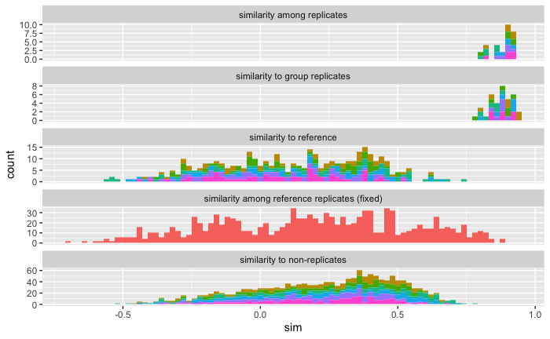

```r
target_guide <- data.frame(
  Metadata_cell_line = "A549",
  Metadata_gene_name = "ITGAV",
  Metadata_pert_name = "ITGAV-2")

display_metrics_distributions(target_guide)
```

```
`guides(<scale> = FALSE)` is deprecated. Please use `guides(<scale> = "none")` instead.
```

| Metadata_cell_line | Metadata_gene_name | Metadata_pert_name | name | value |
| --- | --- | --- | --- | --- |
| A549 | CCND1 | CCND1-1 | sim_scaled_mean_non_rep_g | 0.7812657 |
| A549 | CCND1 | CCND1-1 | sim_mean_g | 0.5786344 |
| A549 | CCND1 | CCND1-1 | sim_scaled_mean_ref_g | 1.0056199 |
| A549 | CCND1 | CCND1-1 | sim_scaled_mean_non_rep_i_mean_i | 0.2153997 |
| A549 | CCND1 | CCND1-1 | sim_mean_i_mean_i | 0.3441279 |
| A549 | CCND1 | CCND1-1 | sim_scaled_mean_ref_i_mean_i | 0.4256980 |

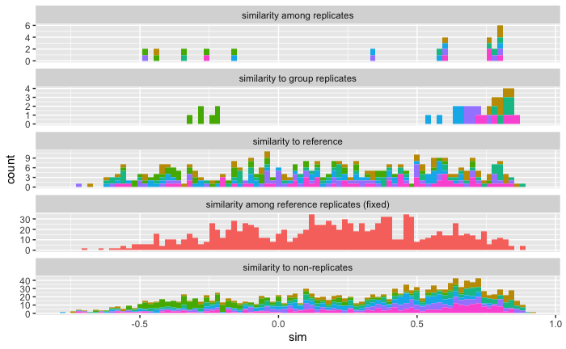

```r
target_guide <- data.frame(
  Metadata_cell_line = "A549",
  Metadata_gene_name = "CCND1",
  Metadata_pert_name = "CCND1-1")

display_metrics_distributions(target_guide)
```

```
`guides(<scale> = FALSE)` is deprecated. Please use `guides(<scale> = "none")` instead.
```

| Metadata_cell_line | Metadata_gene_name | Metadata_pert_name | name | value |
| --- | --- | --- | --- | --- |
| A549 | CCND1 | CCND1-2 | sim_scaled_mean_non_rep_g | 0.4973649 |
| A549 | CCND1 | CCND1-2 | sim_mean_g | 0.5786344 |
| A549 | CCND1 | CCND1-2 | sim_scaled_mean_ref_g | 0.8355366 |
| A549 | CCND1 | CCND1-2 | sim_scaled_mean_non_rep_i_mean_i | 1.2733878 |
| A549 | CCND1 | CCND1-2 | sim_mean_i_mean_i | 0.8893812 |
| A549 | CCND1 | CCND1-2 | sim_scaled_mean_ref_i_mean_i | 1.5815427 |

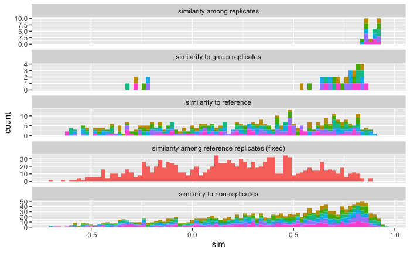

```r
target_guide <- data.frame(
  Metadata_cell_line = "A549",
  Metadata_gene_name = "CCND1",
  Metadata_pert_name = "CCND1-2")

display_metrics_distributions(target_guide)
```

```
`guides(<scale> = FALSE)` is deprecated. Please use `guides(<scale> = "none")` instead.
```

| Metadata_cell_line | Metadata_gene_name | Metadata_pert_name | name | value |
| --- | --- | --- | --- | --- |
| A549 | STAT3 | STAT3-1 | sim_scaled_mean_non_rep_g | 0.26900343 |
| A549 | STAT3 | STAT3-1 | sim_mean_g | 0.18898062 |
| A549 | STAT3 | STAT3-1 | sim_scaled_mean_ref_g | 0.32133262 |
| A549 | STAT3 | STAT3-1 | sim_scaled_mean_non_rep_i_mean_i | -0.16010470 |
| A549 | STAT3 | STAT3-1 | sim_mean_i_mean_i | 0.02433883 |
| A549 | STAT3 | STAT3-1 | sim_scaled_mean_ref_i_mean_i | -0.12163948 |

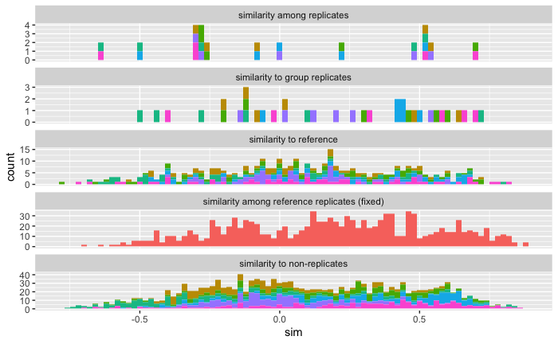

```r
target_guide <- data.frame(
  Metadata_cell_line = "A549",
  Metadata_gene_name = "STAT3",
  Metadata_pert_name = "STAT3-1")

display_metrics_distributions(target_guide)
```

```
`guides(<scale> = FALSE)` is deprecated. Please use `guides(<scale> = "none")` instead.
```

| Metadata_cell_line | Metadata_gene_name | Metadata_pert_name | name | value |
| --- | --- | --- | --- | --- |
| A549 | MYC | MYC-1 | sim_scaled_mean_non_rep_g | 1.5610964 |
| A549 | MYC | MYC-1 | sim_mean_g | 0.8094730 |
| A549 | MYC | MYC-1 | sim_scaled_mean_ref_g | 1.8660963 |
| A549 | MYC | MYC-1 | sim_scaled_mean_non_rep_i_mean_i | 1.6176741 |
| A549 | MYC | MYC-1 | sim_mean_i_mean_i | 0.8240239 |
| A549 | MYC | MYC-1 | sim_scaled_mean_ref_i_mean_i | 1.9028276 |

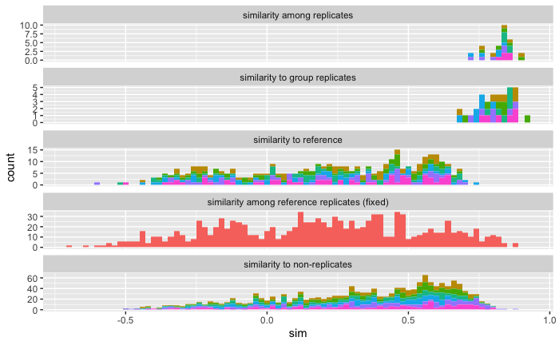

```r
target_guide <- data.frame(
  Metadata_cell_line = "A549",
  Metadata_gene_name = "MYC",
  Metadata_pert_name = "MYC-1")

display_metrics_distributions(target_guide)
```